# Decision Tree Exercise

# 1 Data Understanding

We will work on spam emails.

More details from UCI ML repository:

The “spam” concept is diverse: advertisements for products/web sites, make money fast schemes, chain letters, pornography…

Our collection of spam e-mails came from our postmaster and individuals who had filed spam. Our collection of non-spam e-mails came from filed work and personal e-mails, and hence the word ‘george’ and the area code ‘650’ are indicators of non-spam. These are useful when constructing a personalized spam filter. One would either have to blind such non-spam indicators or get a very wide collection of non-spam to generate a general purpose spam filter.

The last column of ‘spambase.data’ denotes whether the e-mail was considered spam (1) or not (0).

## 1.1 Data Import

```r
# if file does not exist, download it first
file_path <- "./data/spam.csv"
if (!file.exists(file_path)) {
  dir.create("./data")
  url <- "https://archive.ics.uci.edu/ml/machine-learning-databases/spambase/spambase.data"
  download.file(url = url,
                destfile = file_path)
}
```

## 1.2 Packages

We load required packages.

```r
suppressPackageStartupMessages(library(dplyr))
suppressPackageStartupMessages(library(keras))
suppressPackageStartupMessages(library(caret))
suppressPackageStartupMessages(library(rpart))
suppressPackageStartupMessages(library(rpart.plot))

source("./train_val_test_split.R")
```

Import the file to an object called “spam”.

```r
spam <- read.csv('./data/spam.csv', header=F)
spam %>% head()
```

```
##     V1   V2   V3 V4   V5   V6   V7   V8   V9  V10  V11  V12  V13  V14  V15
## 1 0.00 0.64 0.64  0 0.32 0.00 0.00 0.00 0.00 0.00 0.00 0.64 0.00 0.00 0.00
## 2 0.21 0.28 0.50  0 0.14 0.28 0.21 0.07 0.00 0.94 0.21 0.79 0.65 0.21 0.14
## 3 0.06 0.00 0.71  0 1.23 0.19 0.19 0.12 0.64 0.25 0.38 0.45 0.12 0.00 1.75
## 4 0.00 0.00 0.00  0 0.63 0.00 0.31 0.63 0.31 0.63 0.31 0.31 0.31 0.00 0.00
## 5 0.00 0.00 0.00  0 0.63 0.00 0.31 0.63 0.31 0.63 0.31 0.31 0.31 0.00 0.00
## 6 0.00 0.00 0.00  0 1.85 0.00 0.00 1.85 0.00 0.00 0.00 0.00 0.00 0.00 0.00
##    V16  V17  V18  V19  V20  V21 V22  V23  V24 V25 V26 V27 V28 V29 V30 V31
## 1 0.32 0.00 1.29 1.93 0.00 0.96   0 0.00 0.00   0   0   0   0   0   0   0
## 2 0.14 0.07 0.28 3.47 0.00 1.59   0 0.43 0.43   0   0   0   0   0   0   0
## 3 0.06 0.06 1.03 1.36 0.32 0.51   0 1.16 0.06   0   0   0   0   0   0   0
## 4 0.31 0.00 0.00 3.18 0.00 0.31   0 0.00 0.00   0   0   0   0   0   0   0
## 5 0.31 0.00 0.00 3.18 0.00 0.31   0 0.00 0.00   0   0   0   0   0   0   0
## 6 0.00 0.00 0.00 0.00 0.00 0.00   0 0.00 0.00   0   0   0   0   0   0   0
##   V32 V33 V34 V35 V36  V37 V38 V39  V40 V41 V42  V43 V44  V45  V46 V47 V48
## 1   0   0   0   0   0 0.00   0   0 0.00   0   0 0.00   0 0.00 0.00   0   0
## 2   0   0   0   0   0 0.07   0   0 0.00   0   0 0.00   0 0.00 0.00   0   0
## 3   0   0   0   0   0 0.00   0   0 0.06   0   0 0.12   0 0.06 0.06   0   0
## 4   0   0   0   0   0 0.00   0   0 0.00   0   0 0.00   0 0.00 0.00   0   0
## 5   0   0   0   0   0 0.00   0   0 0.00   0   0 0.00   0 0.00 0.00   0   0
## 6   0   0   0   0   0 0.00   0   0 0.00   0   0 0.00   0 0.00 0.00   0   0
##    V49   V50 V51   V52   V53   V54   V55 V56  V57 V58
## 1 0.00 0.000   0 0.778 0.000 0.000 3.756  61  278   1
## 2 0.00 0.132   0 0.372 0.180 0.048 5.114 101 1028   1
## 3 0.01 0.143   0 0.276 0.184 0.010 9.821 485 2259   1
## 4 0.00 0.137   0 0.137 0.000 0.000 3.537  40  191   1
## 5 0.00 0.135   0 0.135 0.000 0.000 3.537  40  191   1
## 6 0.00 0.223   0 0.000 0.000 0.000 3.000  15   54   1
```

# 2 Data Preparation

## 2.1 Column Names

Assign the column names correctly.

```r
col_names_to_set <- c("word_freq_make","word_freq_address","word_freq_all","word_freq_3d","word_freq_our","word_freq_over","word_freq_remove","word_freq_internet","word_freq_order","word_freq_mail","word_freq_receive","word_freq_will","word_freq_people","word_freq_report","word_freq_addresses","word_freq_free","word_freq_business","word_freq_email","word_freq_you","word_freq_credit","word_freq_your","word_freq_font","word_freq_000","word_freq_money","word_freq_hp","word_freq_hpl","word_freq_george","word_freq_650","word_freq_lab","word_freq_labs","word_freq_telnet","word_freq_857","word_freq_data","word_freq_415","word_freq_85","word_freq_technology","word_freq_1999","word_freq_parts","word_freq_pm","word_freq_direct","word_freq_cs","word_freq_meeting","word_freq_original","word_freq_project","word_freq_re","word_freq_edu","word_freq_table","word_freq_conference","char_freq_;","char_freq_(","char_freq_[","char_freq_!","char_freq_$","char_freq_#","capital_run_length_average","capital_run_length_longest","capital_run_length_total", "target"
)

colnames(spam) <- col_names_to_set
```

Check the summary of the data to see if there are missing values. Are there any missing?

```r
summary(spam) # No, the dataset is complete.
```

```
##  word_freq_make   word_freq_address word_freq_all     word_freq_3d
##  Min.   :0.0000   Min.   : 0.000    Min.   :0.0000   Min.   : 0.00000
##  1st Qu.:0.0000   1st Qu.: 0.000    1st Qu.:0.0000   1st Qu.: 0.00000
##  Median :0.0000   Median : 0.000    Median :0.0000   Median : 0.00000
##  Mean   :0.1046   Mean   : 0.213    Mean   :0.2807   Mean   : 0.06542
##  3rd Qu.:0.0000   3rd Qu.: 0.000    3rd Qu.:0.4200   3rd Qu.: 0.00000
##  Max.   :4.5400   Max.   :14.280    Max.   :5.1000   Max.   :42.81000
##  word_freq_our     word_freq_over   word_freq_remove word_freq_internet
##  Min.   : 0.0000   Min.   :0.0000   Min.   :0.0000   Min.   : 0.0000
##  1st Qu.: 0.0000   1st Qu.:0.0000   1st Qu.:0.0000   1st Qu.: 0.0000
##  Median : 0.0000   Median :0.0000   Median :0.0000   Median : 0.0000
##  Mean   : 0.3122   Mean   :0.0959   Mean   :0.1142   Mean   : 0.1053
##  3rd Qu.: 0.3800   3rd Qu.:0.0000   3rd Qu.:0.0000   3rd Qu.: 0.0000
##  Max.   :10.0000   Max.   :5.8800   Max.   :7.2700   Max.   :11.1100
##  word_freq_order   word_freq_mail    word_freq_receive word_freq_will
##  Min.   :0.00000   Min.   : 0.0000   Min.   :0.00000   Min.   :0.0000
##  1st Qu.:0.00000   1st Qu.: 0.0000   1st Qu.:0.00000   1st Qu.:0.0000
##  Median :0.00000   Median : 0.0000   Median :0.00000   Median :0.1000
##  Mean   :0.09007   Mean   : 0.2394   Mean   :0.05982   Mean   :0.5417
##  3rd Qu.:0.00000   3rd Qu.: 0.1600   3rd Qu.:0.00000   3rd Qu.:0.8000
##  Max.   :5.26000   Max.   :18.1800   Max.   :2.61000   Max.   :9.6700
##  word_freq_people  word_freq_report   word_freq_addresses
##  Min.   :0.00000   Min.   : 0.00000   Min.   :0.0000
##  1st Qu.:0.00000   1st Qu.: 0.00000   1st Qu.:0.0000
##  Median :0.00000   Median : 0.00000   Median :0.0000
##  Mean   :0.09393   Mean   : 0.05863   Mean   :0.0492
##  3rd Qu.:0.00000   3rd Qu.: 0.00000   3rd Qu.:0.0000
##  Max.   :5.55000   Max.   :10.00000   Max.   :4.4100
##  word_freq_free    word_freq_business word_freq_email  word_freq_you
##  Min.   : 0.0000   Min.   :0.0000     Min.   :0.0000   Min.   : 0.000
##  1st Qu.: 0.0000   1st Qu.:0.0000     1st Qu.:0.0000   1st Qu.: 0.000
##  Median : 0.0000   Median :0.0000     Median :0.0000   Median : 1.310
##  Mean   : 0.2488   Mean   :0.1426     Mean   :0.1847   Mean   : 1.662
##  3rd Qu.: 0.1000   3rd Qu.:0.0000     3rd Qu.:0.0000   3rd Qu.: 2.640
##  Max.   :20.0000   Max.   :7.1400     Max.   :9.0900   Max.   :18.750
##  word_freq_credit   word_freq_your    word_freq_font    word_freq_000
##  Min.   : 0.00000   Min.   : 0.0000   Min.   : 0.0000   Min.   :0.0000
##  1st Qu.: 0.00000   1st Qu.: 0.0000   1st Qu.: 0.0000   1st Qu.:0.0000
##  Median : 0.00000   Median : 0.2200   Median : 0.0000   Median :0.0000
##  Mean   : 0.08558   Mean   : 0.8098   Mean   : 0.1212   Mean   :0.1016
```

[output cut: 57 more lines]

```
##  Max.   :32.4780   Max.   :6.00300   Max.   :19.82900
##  capital_run_length_average capital_run_length_longest
##  Min.   :   1.000           Min.   :   1.00
##  1st Qu.:   1.588           1st Qu.:   6.00
##  Median :   2.276           Median :  15.00
##  Mean   :   5.191           Mean   :  52.17
##  3rd Qu.:   3.706           3rd Qu.:  43.00
##  Max.   :1102.500           Max.   :9989.00
##  capital_run_length_total     target
##  Min.   :    1.0          Min.   :0.000
##  1st Qu.:   35.0          1st Qu.:0.000
##  Median :   95.0          Median :0.000
##  Mean   :  283.3          Mean   :0.394
##  3rd Qu.:  266.0          3rd Qu.:1.000
##  Max.   :15841.0          Max.   :1.000
```

Transform the target variable to factors.

```r
spam$target <- as.factor(spam$target)
summary(spam$target)
```

```
##    0    1
## 2788 1813
```

```r
2788/length(spam$target) # Naive Classifier as Baseline, because data is not balanced.
```

```
## [1] 0.6059552
```

## 2.2 Train / Validation / Test Split

Split the data into train, validation, and test data. Use splitting ratios of 80% training, 20% validation.

```r
set.seed(123)
c(train, val, test) %<-% train_val_test_split(spam, train_ratio =0.8, val_ratio = 0.2, test_ratio = 0)
```

# 3 Modeling

## 3.1 Model Creation

Create a decision tree model for target-variable. Take all other parameters into account.

```r
set.seed(123)
decision_tree_fit <- rpart(formula=target ~ .,
                           data=train)
```

## 3.2 Visualisation

Create a visualisation which shows the decision tree.

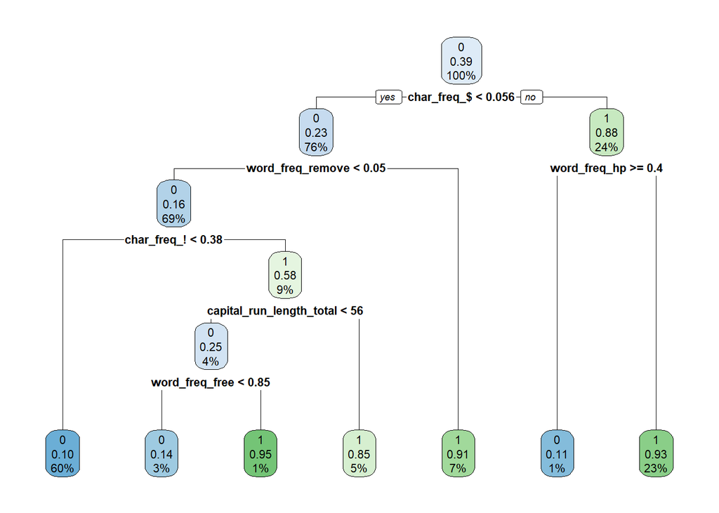

```r
rpart.plot(decision_tree_fit)
```

# 4 Predictions

Create predictions for train, and validation data. These will be probabilities.

```r
train$target_predictions <- predict(decision_tree_fit,
                                    newdata=train)[,2] # Why does it produce double the length when we don't put []?

val$target_predictions <- predict(decision_tree_fit,
                                    newdata=val)[,2]
```

Based on probablitites we want to derive class predictions. Please use of threshold of 0.5 for assignment of classes.

```r
train$target_predictions_class <- ifelse(train$target_predictions > 0.5, 1, 0)
val$target_predictions_class <- ifelse(val$target_predictions > 0.5, 1, 0)
```

# 5 Model Performance

We will compare our classifier to the baseline classifier.

## 5.1 Baseline Classifier

Please calculate the baseline classifier (assignment to most frequent class).

```r
2788/length(spam$target) # Naive Classifier as Baseline, because data is not balanced.
```

```
## [1] 0.6059552
```

## 5.2 Confusion Matrix

Calculate a confusion matrix for Training Data:

```r
cm_train <- table(actual = train$target, predicted = train$target_predictions_class)
cm_train
```

```
##       predicted
## actual    0    1
##      0 2130  109
##      1  246 1195
```

Calculate a confusion matrix for Validation Data:

```r
cm_val <- table(actual = val$target, predicted = val$target_predictions_class)
cm_val
```

```
##       predicted
## actual   0   1
##      0 523  26
##      1  67 304
```

Calculate the Accuracy from the confusion matrix (for training and validation data).

```r
acc_train <- sum(diag(cm_train))/sum(cm_train)
acc_train
```

```
## [1] 0.9035326
```

```r
acc_val <- sum(diag(cm_val))/sum(cm_val)
acc_val
```

```
## [1] 0.898913
```

Is our classifier superior to baseline classifier?

```r
# Yes, it is higher than the calculated 0.61 naive classifier.
```

# 6 Acknowledgement

We thank the creators and authors of the dataset.

Creators:

Mark Hopkins, Erik Reeber, George Forman, Jaap Suermondt Hewlett-Packard Labs, 1501 Page Mill Rd., Palo Alto, CA 94304

Donor:

George Forman (gforman at nospam hpl.hp.com) 650-857-7835